# Predicting the possibility of rain and assessing how the different environmental factors affect the amount of rainfall received in Australia

## Project done by: V.M.KARTHIK SAI

### Setup - Imported Australia Weather Dataset

### Source of Dataset - Kaggle - (https://www.kaggle.com/datasets/jsphyg/weather-dataset-rattle-package)

### Loading the required packages

```r
rm(list=ls())
library(dplyr)
```

```r
library(ggplot2)
library(caret)
library(mice)
library(caTools)
library(e1071)
library(class)
```

### About the problem statement:

### I am predicting the possibility of rain and assessing how the different environmental factors affect the amount of rainfall received in Australia.

### Chosen Dataset - Australian Weather Dataset

```r
setwd("/Users/karthiksaivm/Documents/Personal Projects")
waus<-read.csv("weatherAUS.csv")
set.seed(369)
```

### Description of Dataset: Australian Weather Dataset - This dataset contains more than 145,000 records of weather data from 2007 and 2017.

### Preparing the Dataset

```r
#Changing "chr" datatype to "Date.format" for the Date column
waus<-waus%>%
  mutate(date=as.Date(Date))
waus$Date<-NULL
waus<-waus%>%
  rename(Date=date)

#Making new columns(Day,Month,Year) from the existing Date column
waus<-waus%>%
  mutate(Month=months(Date))
waus[, "Year"] <- format(waus[,"Date"], "%Y")
waus$Year<-as.numeric(waus$Year)
waus[, "Day"] <- format(waus[,"Date"], "%d")
waus$Day<-as.numeric(waus$Day)
waus<-waus%>%
  select(Year, everything())
waus<-waus%>%
  select(Month, everything())
waus<-waus%>%
  select(Day, everything())
waus<-waus%>%
  select(Location, everything())
waus<-waus%>%
  select(Date, everything())

#Ordering the dates in ascending order for the Date column
waus<-waus[order(waus$Date, decreasing = FALSE),]

#Adding a new column - ID in the waus dataset
waus$ID<-seq.int(nrow(waus))
waus<-waus%>%
  select(ID, everything())

#wausmv dataset contains all the columns that have missing values in the waus dataset
wausmv<-subset(waus,select=-c(Date,Location,WindGustDir,WindDir9am,WindDir3pm,RainToday,RainTomorrow,Month,Year,Day))

#Data Imputation done using the pmm(predictive mean matching) method with the help of the mice package
impdat<-mice(wausmv,m=5,maxit=5,seed=500)
#nwaus dataset contains all the imputed values for all the columns in the wausmv dataset
nwaus<-complete(impdat,3)

#Adding a new column - ID in the nwaus dataset
nwaus$ID<-seq.int(nrow(nwaus))
nwaus<-nwaus%>%
  select(ID, everything())

#wausnmv dataset contains all the columns that do not have missing values in the waus dataset
wausnmv<-subset(waus,select=c(ID,Date,Location,WindGustDir,WindDir9am,WindDir3pm,RainToday,RainTomorrow,Month,Year,Day))

#fwaus dataset is obtained after merging the nwaus dataset and the wausnmv dataset by the common ID column
fwaus<-merge(nwaus,wausnmv,by="ID")
fwaus<-fwaus%>%
  select(Year, everything())
fwaus<-fwaus%>%
  select(Month, everything())
fwaus<-fwaus%>%
  select(Day, everything())
fwaus<-fwaus%>%
  select(Location, everything())
fwaus<-fwaus%>%
  select(Date, everything())
fwaus<-fwaus%>%
  select(ID, everything())
```

### Basic commands to describe dataset:

### 1

```r
str(fwaus)
```

```
## 'data.frame':    145460 obs. of  27 variables:
##  $ ID           : int  1 2 3 4 5 6 7 8 9 10 ...
##  $ Date         : Date, format: "2007-11-01" "2007-11-02" ...
##  $ Location     : chr  "Canberra" "Canberra" "Canberra" "Canberra" ...
##  $ Day          : num  1 2 3 4 5 6 7 8 9 10 ...
##  $ Month        : chr  "November" "November" "November" "November" ...
##  $ Year         : num  2007 2007 2007 2007 2007 ...
##  $ MinTemp      : num  8 14 13.7 13.3 7.6 6.2 6.1 8.3 8.8 8.4 ...
##  $ MaxTemp      : num  24.3 26.9 23.4 15.5 16.1 16.9 18.2 17 19.5 22.8 ...
##  $ Rainfall     : num  0 3.6 3.6 39.8 2.8 0 0.2 0 0 16.2 ...
##  $ Evaporation  : num  3.4 4.4 5.8 7.2 5.6 5.8 4.2 5.6 4 5.4 ...
##  $ Sunshine     : num  6.3 9.7 3.3 9.1 10.6 8.2 8.4 4.6 4.1 7.7 ...
##  $ WindGustSpeed: int  30 39 85 54 50 44 43 41 48 31 ...
##  $ WindSpeed9am : int  6 4 6 30 20 20 19 11 19 7 ...
##  $ WindSpeed3pm : int  20 17 6 24 28 24 26 24 17 6 ...
##  $ Humidity9am  : int  68 80 82 62 68 70 63 65 70 82 ...
##  $ Humidity3pm  : int  29 36 69 56 49 57 47 57 48 32 ...
##  $ Pressure9am  : num  1020 1012 1010 1006 1018 ...
##  $ Pressure3pm  : num  1015 1008 1007 1007 1018 ...
##  $ Cloud9am     : int  7 5 8 2 7 7 4 6 7 7 ...
##  $ Cloud3pm     : int  7 3 7 7 7 5 6 7 7 1 ...
##  $ Temp9am      : num  14.4 17.5 15.4 13.5 11.1 10.9 12.4 12.1 14.1 13.3 ...
##  $ Temp3pm      : num  23.6 25.7 20.2 14.1 15.4 14.8 17.3 15.5 18.9 21.7 ...
##  $ WindGustDir  : chr  "NW" "ENE" "NW" "NW" ...
##  $ WindDir9am   : chr  "SW" "E" "N" "WNW" ...
##  $ WindDir3pm   : chr  "NW" "W" "NNE" "W" ...
##  $ RainToday    : chr  "No" "Yes" "Yes" "Yes" ...
##  $ RainTomorrow : chr  "Yes" "Yes" "Yes" "Yes" ...
```

### 2

```r
dim(fwaus)
```

```
## [1] 145460     27
```

### 3

```r
class(fwaus)
```

```
## [1] "data.frame"
```

### 4

```r
typeof(fwaus)
```

```
## [1] "list"
```

### 5

```r
names(fwaus)
```

```
##  [1] "ID"            "Date"          "Location"      "Day"
##  [5] "Month"         "Year"          "MinTemp"       "MaxTemp"
##  [9] "Rainfall"      "Evaporation"   "Sunshine"      "WindGustSpeed"
## [13] "WindSpeed9am"  "WindSpeed3pm"  "Humidity9am"   "Humidity3pm"
## [17] "Pressure9am"   "Pressure3pm"   "Cloud9am"      "Cloud3pm"
## [21] "Temp9am"       "Temp3pm"       "WindGustDir"   "WindDir9am"
## [25] "WindDir3pm"    "RainToday"     "RainTomorrow"
```

### 6

```r
summary(fwaus)
```

```
##        ID              Date              Location              Day
##  Min.   :     1   Min.   :2007-11-01   Length:145460      Min.   : 1.00
##  1st Qu.: 36366   1st Qu.:2011-01-11   Class :character   1st Qu.: 8.00
##  Median : 72730   Median :2013-06-02   Mode  :character   Median :16.00
##  Mean   : 72730   Mean   :2013-04-04                      Mean   :15.71
##  3rd Qu.:109095   3rd Qu.:2015-06-14                      3rd Qu.:23.00
##  Max.   :145460   Max.   :2017-06-25                      Max.   :31.00
##     Month                Year         MinTemp        MaxTemp
##  Length:145460      Min.   :2007   Min.   :-8.5   Min.   :-4.80
##  Class :character   1st Qu.:2011   1st Qu.: 7.6   1st Qu.:17.90
##  Mode  :character   Median :2013   Median :12.0   Median :22.60
##                     Mean   :2013   Mean   :12.2   Mean   :23.22
##                     3rd Qu.:2015   3rd Qu.:16.9   3rd Qu.:28.20
##                     Max.   :2017   Max.   :33.9   Max.   :48.10
##     Rainfall        Evaporation         Sunshine      WindGustSpeed
##  Min.   :  0.000   Min.   :  0.000   Min.   : 0.000   Min.   :  6.00
##  1st Qu.:  0.000   1st Qu.:  2.400   1st Qu.: 4.400   1st Qu.: 30.00
##  Median :  0.000   Median :  4.400   Median : 8.200   Median : 39.00
##  Mean   :  2.368   Mean   :  5.159   Mean   : 7.394   Mean   : 39.83
##  3rd Qu.:  0.800   3rd Qu.:  7.000   3rd Qu.:10.600   3rd Qu.: 48.00
##  Max.   :371.000   Max.   :145.000   Max.   :14.500   Max.   :135.00
##   WindSpeed9am     WindSpeed3pm    Humidity9am      Humidity3pm
##  Min.   :  0.00   Min.   : 0.00   Min.   :  0.00   Min.   :  0.0
##  1st Qu.:  7.00   1st Qu.:13.00   1st Qu.: 57.00   1st Qu.: 37.0
##  Median : 13.00   Median :19.00   Median : 70.00   Median : 52.0
##  Mean   : 14.04   Mean   :18.65   Mean   : 68.93   Mean   : 51.6
##  3rd Qu.: 19.00   3rd Qu.:24.00   3rd Qu.: 83.00   3rd Qu.: 66.0
##  Max.   :130.00   Max.   :87.00   Max.   :100.00   Max.   :100.0
##   Pressure9am      Pressure3pm        Cloud9am        Cloud3pm
##  Min.   : 980.5   Min.   : 977.1   Min.   :0.000   Min.   :0.00
##  1st Qu.:1013.0   1st Qu.:1010.5   1st Qu.:1.000   1st Qu.:2.00
##  Median :1017.7   Median :1015.3   Median :5.000   Median :5.00
##  Mean   :1017.7   Mean   :1015.3   Mean   :4.394   Mean   :4.49
##  3rd Qu.:1022.4   3rd Qu.:1020.0   3rd Qu.:7.000   3rd Qu.:7.00
##  Max.   :1041.0   Max.   :1039.6   Max.   :9.000   Max.   :9.00
##     Temp9am         Temp3pm      WindGustDir         WindDir9am
##  Min.   :-7.20   Min.   :-5.40   Length:145460      Length:145460
##  1st Qu.:12.30   1st Qu.:16.60   Class :character   Class :character
##  Median :16.70   Median :21.10   Mode  :character   Mode  :character
##  Mean   :16.96   Mean   :21.71
##  3rd Qu.:21.50   3rd Qu.:26.50
##  Max.   :40.20   Max.   :46.70
##   WindDir3pm         RainToday         RainTomorrow
##  Length:145460      Length:145460      Length:145460
##  Class :character   Class :character   Class :character
##  Mode  :character   Mode  :character   Mode  :character
##
##
##
```

### My objectives:

### 1. To find out the which locations in Australia had maximum and minimum number of rainy and non rainy days across 10 years.

```r
rdaus <- fwaus %>%
  filter(RainToday == "Yes") %>%
  select(Location) %>%
  table() %>%
  as.data.frame()

rdaus <- rdaus %>%
  rename(Location = 1, Number_of_rainy_days = 2)

#Location in Australia with maximum of rainy days across 10 years
rdaus[which.max(rdaus$Number_of_rainy_days),]
```

```
##    Location Number_of_rainy_days
## 34 Portland                 1094
```

### Inference: The location with the maximum number of rainy days was found to be Portland.

```r
#Location in Australia with minimum of rainy days across 10 years
rdaus[which.min(rdaus$Number_of_rainy_days),]
```

```
##    Location Number_of_rainy_days
## 42    Uluru                  116
```

```r
nrdaus <- fwaus %>%
  filter(RainToday == "No") %>%
  select(Location) %>%
  table() %>%
  as.data.frame()

nrdaus <- nrdaus %>%
  rename(Location = 1, Number_of_non_rainy_days = 2)
```

### Inference: The location with the minimum number of rainy days was found to be Uluru.

```r
#Location in Australia with maximum of non rainy days across 10 years
nrdaus[which.max(nrdaus$Number_of_non_rainy_days),]
```

```
##    Location Number_of_non_rainy_days
## 10 Canberra                     2789
```

```r
nrdaus%>%
  filter(Number_of_non_rainy_days==2789)
```

```
##   Location Number_of_non_rainy_days
## 1 Canberra                     2789
## 2  Woomera                     2789
```

### Inference: The location with the maximum number of non rainy days was found to be Canberra and Woomera.

```r
#Location in Australia with minimum of non rainy days across 10 years
nrdaus[which.min(nrdaus$Number_of_non_rainy_days),]
```

```
##     Location Number_of_non_rainy_days
## 17 Katherine                     1295
```

### Inference: The location with the minimum number of non rainy days was found to be Katherine.

### 2. Observing the rain activity for different years and different months in a year

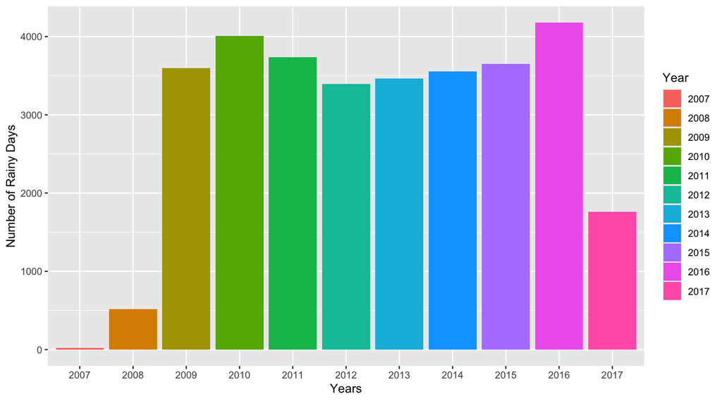

```r
lfwaus<-fwaus
lfwaus$Year<-as.character(lfwaus$Year)

ggplot(lfwaus %>% filter(RainToday=="Yes") %>% select(Year),aes(x=Year,fill=Year)) + geom_bar()+xlab("Years")+ylab("Number of Rainy Days")
```

### Inference: ### When observing the number of rainy days, 2010 and 2016 seem to have greater than 4000 rainy days which is higher compared to other years.

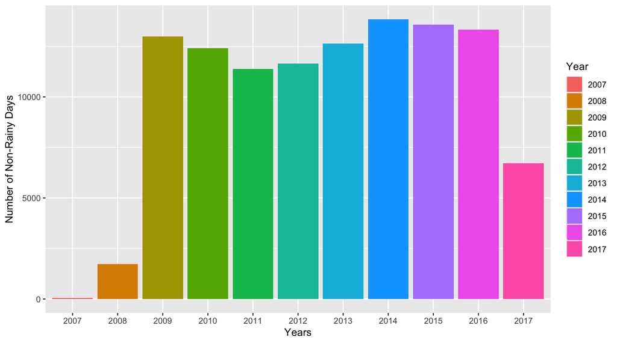

```r
ggplot(lfwaus %>% filter(RainToday=="No") %>% select(Year),aes(x=Year,fill=Year)) + geom_bar()+xlab("Years")+ylab("Number of Non-Rainy Days")
```

### Inference: ### When observing the number of non-rainy days, 2009, 2013, 2014, 2015 and 2016 months seem to have greater than 12500 non-rainy days which is higher compared to other years. ### It can be clearly seen that the number of non-rainy days is far greater than the number of rainy days in Australia based on the y-axis values.

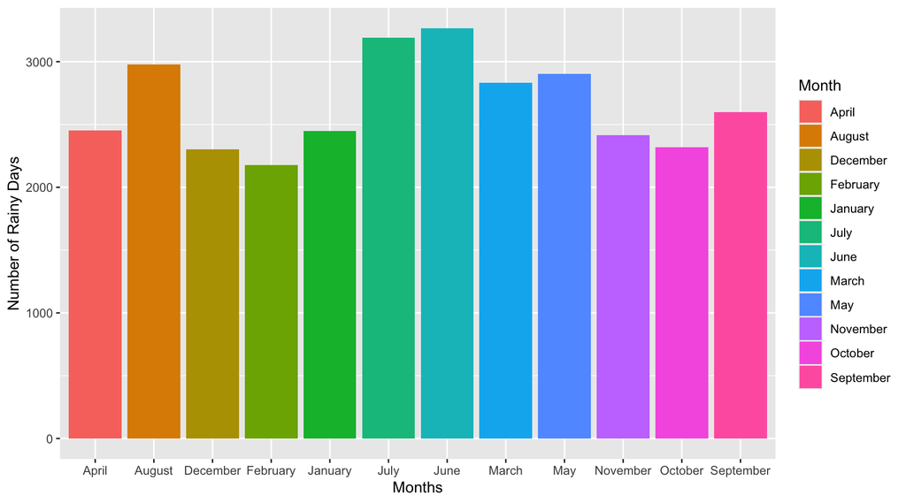

```r
ggplot(lfwaus %>% filter(RainToday=="Yes") %>% select(Month),aes(x=Month,fill=Month)) + geom_bar() +xlab("Months") +ylab("Number of Rainy Days")
```

### Inference: ### When observing the number of rainy days, June and July months seem to have greater than 3000 rainy days which is higher compared to other months in a year.

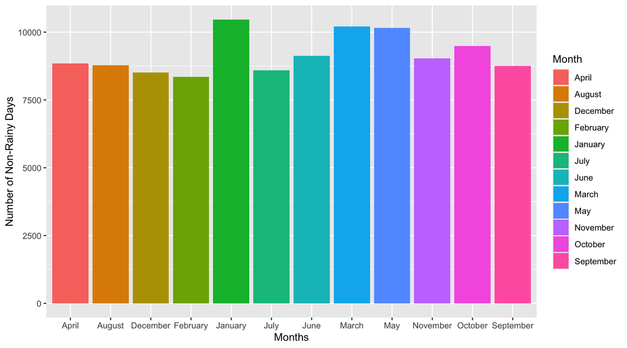

```r
ggplot(lfwaus %>% filter(RainToday=="No") %>% select(Month),aes(x=Month,fill=Month)) + geom_bar() +xlab("Months") +ylab("Number of Non-Rainy Days")
```

### Inference: ### When observing the number of non-rainy days, January, March and May months seem to have greater than 10000 non-rainy days which is higher compared to other months in a year.

### 3. Locations in Australia where Class A pan evaporation is greater than 70mm in the 24 hours to 9am from 2007 to 2017

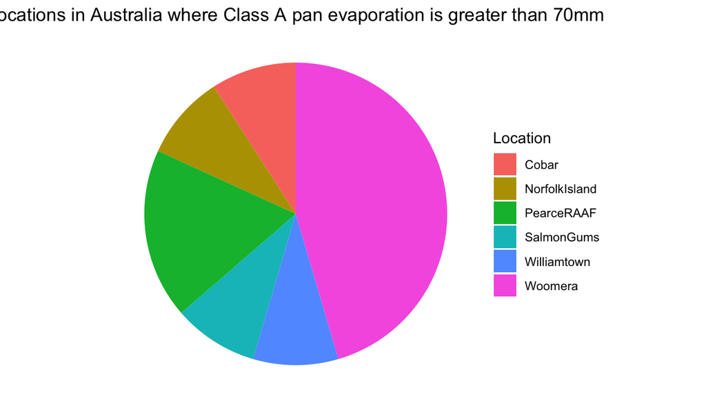

```r
ggplot(fwaus %>% filter(Evaporation>70), aes(y="",fill=Location)) + geom_bar(position = 'stack', width = 3) +coord_polar() +theme_void() + ggtitle("Locations in Australia where Class A pan evaporation is greater than 70mm")+theme(plot.title = element_text(hjust = 0.5))
```

### Inference:

### Among the six locations, Woomera seems to have the highest occurences for Class A pan evaporation greater than 70mm in the 24 hours to 9am from 2007 to 2017. This shows that Woomera would be a location having hot, dry and windy climates.

### 4. Observing high wind speed and high temperature at two different sections of years for different days in the week from 2007 to 2012 (fisrt section) and from 2013 to 2017 (second section)

```r
wfwaus<-fwaus%>%
  mutate(Weekday=weekdays(Date))
```

### High Wind Speed

[figure not shown]

```r
ggplot(wfwaus %>% filter(WindSpeed9am>40 & Year<2013) %>% select(Weekday),aes(x=Weekday,fill=Weekday)) + geom_bar()+xlab("Days of the Week")+ylab("Number of occurences for Wind Speed greater than 14 km/hr")+ggtitle("High Wind Speed (km/hr) averaged over 10 minutes prior to 9am (2007-2012)")
```

### Inference: ### High Wind Speed averaged over 10 minutes prior to 9am: ### First Section (2007-2012): ### Saturday seems to have the highest occurence and Monday seems to have the lowest occurence among the 7 days of the week.

[figure not shown]

```r
ggplot(wfwaus %>% filter(WindSpeed9am>40 & Year>2012) %>% select(Weekday),aes(x=Weekday,fill=Weekday)) + geom_bar()+xlab("Days of the Week")+ylab("Number of occurences for Wind Speed greater than 14 km/hr")+ggtitle("High Wind Speed (km/hr) averaged over 10 minutes prior to 9am (2013-2017)")
```

### Inference: ### High Wind Speed averaged over 10 minutes prior to 9am: ### Second Section (2013-2017): ### Thursday seems to have the highest occurence and Saturday seems to have the lowest occurence among the 7 days of the week.

[figure not shown]

```r
ggplot(wfwaus %>% filter(WindSpeed3pm>40 & Year<2013) %>% select(Weekday),aes(x=Weekday,fill=Weekday)) + geom_bar()+xlab("Days of the Week")+ylab("Number of occurences for Wind Speed greater than 19 km/hr")+ggtitle("High Wind Speed (km/hr) averaged over 10 minutes prior to 3pm (2007-2012)")
```

### Inference: ### High Wind Speed averaged over 10 minutes prior to 3pm: ### First Section (2007-2012): ### Tuesday seems to have the highest occurence and Monday seems to have the lowest occurence among the 7 days of the week.

[figure not shown]

```r
ggplot(wfwaus %>% filter(WindSpeed3pm>40 & Year>2012) %>% select(Weekday),aes(x=Weekday,fill=Weekday)) + geom_bar()+xlab("Days of the Week")+ylab("Number of occurences for Wind Speed greater than 19 km/hr")+ggtitle("High Wind Speed (km/hr) averaged over 10 minutes prior to 3pm (2013-2017)")
```

### Inference: ### High Wind Speed averaged over 10 minutes prior to 3pm: ### Second Section (2013-2017): ### Tuesday seems to have the highest occurence and Wednesday seems to have the lowest occurence among the 7 days of the week.

# High Temperature

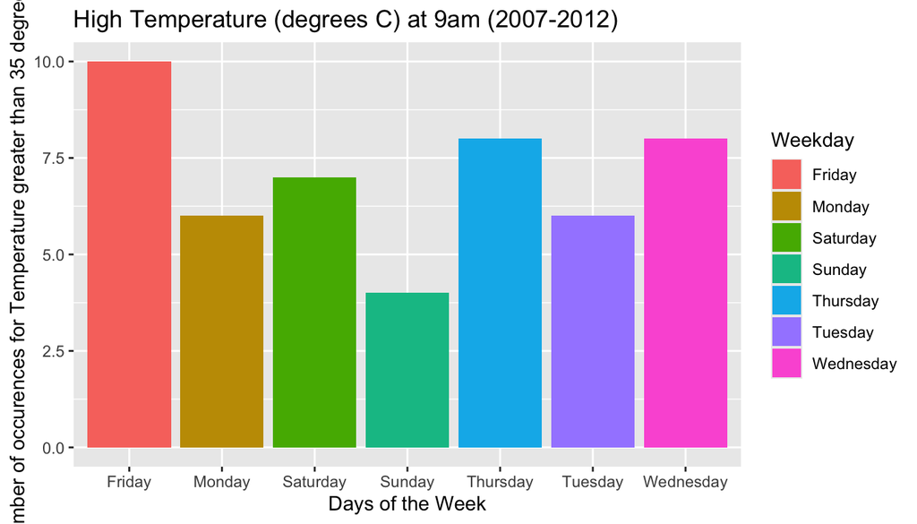

```r
ggplot(wfwaus %>% filter(Temp9am>35 & Year<2013) %>% select(Weekday),aes(x=Weekday,fill=Weekday)) + geom_bar()+xlab("Days of the Week")+ylab("Number of occurences for Temperature greater than 35 degrees C")+ggtitle("High Temperature (degrees C) at 9am (2007-2012)")
```

### Inference: ### High Temperature at 9am ### First Section (2007-2012): ### Friday seems to have the highest occurence and Sunday seems to have the lowest occurence among the 7 days of the week.

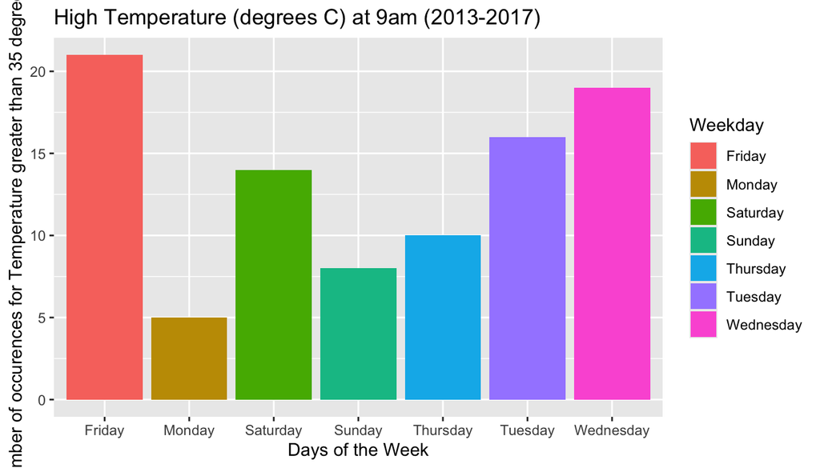

```r
ggplot(wfwaus %>% filter(Temp9am>35 & Year>2012) %>% select(Weekday),aes(x=Weekday,fill=Weekday)) + geom_bar()+xlab("Days of the Week")+ylab("Number of occurences for Temperature greater than 35 degrees C")+ggtitle("High Temperature (degrees C) at 9am (2013-2017)")
```

### Inference: ### High Temperature at 9am ### Second Section (2013-2017): ### Friday seems to have the highest occurence and Monday seems to have the lowest occurence among the 7 days of the week.

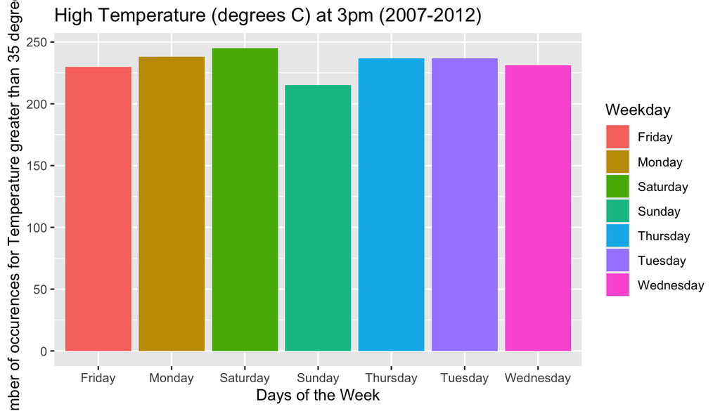

```r
ggplot(wfwaus %>% filter(Temp3pm>35 & Year<2013) %>% select(Weekday),aes(x=Weekday,fill=Weekday)) + geom_bar()+xlab("Days of the Week")+ylab("Number of occurences for Temperature greater than 35 degrees C")+ggtitle("High Temperature (degrees C) at 3pm (2007-2012)")
```

### Inference: ### High Temperature at 3pm: ### First Section (2007-2012): ### Saturday seems to have the highest occurence and Sunday seems to have the lowest occurence among the 7 days of the week.

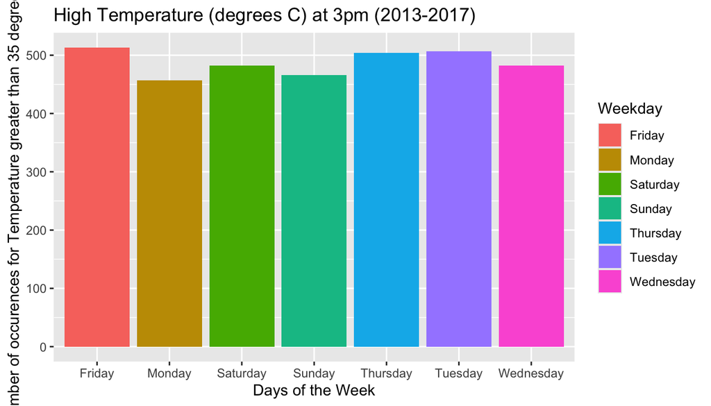

```r
ggplot(wfwaus %>% filter(Temp3pm>35 & Year>2012) %>% select(Weekday),aes(x=Weekday,fill=Weekday)) + geom_bar()+xlab("Days of the Week")+ylab("Number of occurences for Temperature greater than 35 degrees C")+ggtitle("High Temperature (degrees C) at 3pm (2013-2017)")
```

### Inference: ### High Temperature at 3pm: ### Second Section (2013-2017): ### Friday seems to have the highest occurence and Monday seems to have the lowest occurence among the 7 days of the week.

### 5. To find out what environmental factors are responsible for causing the next day to rain in Australia.

```r
n0fwaus<-fwaus%>%
  filter(RainTomorrow=="Yes")
r0<-round(colMeans(n0fwaus[,7:22], na.rm = TRUE))
n1fwaus<-fwaus%>%
  filter(RainTomorrow=="No")
r1<-round(colMeans(n1fwaus[,7:22], na.rm = TRUE))
r0-r1
```

```
##       MinTemp       MaxTemp      Rainfall   Evaporation      Sunshine
##             1            -3             5            -1            -3
## WindGustSpeed  WindSpeed9am  WindSpeed3pm   Humidity9am   Humidity3pm
##             7             2             2            12            22
##   Pressure9am   Pressure3pm      Cloud9am      Cloud3pm       Temp9am
##            -4            -3             2             2             0
##       Temp3pm
##            -3
```

```r
table(n0fwaus$WindGustDir)
```

```
##
##    E  ENE  ESE    N   NE  NNE  NNW   NW    S   SE  SSE  SSW   SW    W  WNW  WSW
## 1350 1288 1200 2452 1319 1481 1863 2284 2017 1733 1755 1897 1804 2607 2275 2085
```

```r
which.max(table(n0fwaus$WindGustDir))
```

```
##  W
## 14
```

```r
which.min(table(n0fwaus$WindGustDir))
```

```
## ESE
##   3
```

```r
table(n0fwaus$WindDir9am)
```

```
##
##    E  ENE  ESE    N   NE  NNE  NNW   NW    S   SE  SSE  SSW   SW    W  WNW  WSW
## 1315 1365 1118 3510 1568 2137 2430 2389 1681 1491 1601 1645 1909 2157 1948 1692
```

```r
which.max(table(n0fwaus$WindDir9am))
```

```
## N
## 4
```

```r
which.min(table(n0fwaus$WindDir9am))
```

```
## ESE
##   3
```

```r
table(n0fwaus$WindDir3pm)
```

```
##
##    E  ENE  ESE    N   NE  NNE  NNW   NW    S   SE  SSE  SSW   SW    W  WNW  WSW
## 1429 1382 1421 2421 1541 1577 2186 2393 2075 2031 1750 1789 1808 2528 2400 2093
```

```r
which.max(table(n0fwaus$WindDir3pm))
```

```
##  W
## 14
```

```r
which.min(table(n0fwaus$WindDir3pm))
```

```
## ENE
##   2
```

### Inference:

### For the next day to rain in Australia:

### When subtracting r1 (Dataset with means of columns 7-22 with RainTomorrow=“No”) from r0 (Dataset with means of columns 7-22 with RainTomorrow=“Yes”), it shows that Rainfall, WindGustSpeed, Humidity9am, Humidity3pm show a positive significant difference and Pressure9am shows a negative significant difference.

### The highest occurence for wind gust direction is West and lowest occurence for wind gust direction is East-Southeast.

### The highest occurence for wind direction at 9am is North and lowest occurence for wind direction at 9am is East-Southeast.

### The highest occurence for wind direction at 3pm is West and lowest occurence for wind direction at 3pm is East-Northeast.

```r
table(n1fwaus$WindGustDir)
```

```
##
##    E  ENE  ESE    N   NE  NNE  NNW   NW    S   SE  SSE  SSW   SW    W  WNW  WSW
## 7721 6704 6105 6581 5741 4952 4698 5719 6932 7576 7238 6713 6993 7173 5791 6816
```

```r
which.max(table(n1fwaus$WindGustDir))
```

```
## E
## 1
```

```r
which.min(table(n1fwaus$WindGustDir))
```

```
## NNW
##   7
```

```r
table(n1fwaus$WindDir9am)
```

```
##
##    E  ENE  ESE    N   NE  NNE  NNW   NW    S   SE  SSE  SSW   SW    W  WNW  WSW
## 7709 6370 6440 7883 5959 5811 5410 6163 6812 7671 7365 5803 6328 6103 5246 5151
```

```r
which.max(table(n1fwaus$WindDir9am))
```

```
## N
## 4
```

```r
which.min(table(n1fwaus$WindDir9am))
```

```
## WSW
##  16
```

```r
table(n1fwaus$WindDir3pm)
```

```
##
##    E  ENE  ESE    N   NE  NNE  NNW   NW    S   SE  SSE  SSW   SW    W  WNW  WSW
## 6913 6342 6961 6246 6623 4867 5547 6075 7523 8632 7392 6221 7374 7383 6256 7236
```

```r
which.max(table(n1fwaus$WindDir3pm))
```

```
## SE
## 10
```

```r
which.min(table(n0fwaus$WindDir3pm))
```

```
## ENE
##   2
```

### 6. To predict the possibility of rain for the next day in any location based on the environmental factors in Australia.

### Using three classification algorithms, I am trying to find out which classification algorithm is the best to predict the outcome variable which is “RainTommorow”.

### Linear Kernel

```r
f1waus<-fwaus[7:22]
f1waus$ID<-seq.int(nrow(f1waus))
f1waus<-f1waus%>%
  select(ID, everything())
f2waus<-fwaus[27]
f2waus$ID<-seq.int(nrow(f2waus))
f2waus<-f2waus%>%
  select(ID, everything())
f3waus<-merge(f1waus,f2waus,by="ID")
dataset = f3waus[2:18]

dataset$RainTomorrow = factor(dataset$RainTomorrow, levels = c('Yes','No'))

split = sample.split(dataset$RainTomorrow, SplitRatio = 0.75)

training_set = subset(dataset, split == TRUE)
test_set = subset(dataset, split == FALSE)

training_set[-17] = scale(training_set[-17])
test_set[-17] = scale(test_set[-17])

classifier = svm(formula = RainTomorrow ~ .,
                 data = training_set,
                 type = 'C-classification',
                 kernel = 'linear')

y_pred = predict(classifier, newdata = test_set[-17])

confusionMatrix(table(y_pred,test_set$RainTomorrow))
```

```
## Confusion Matrix and Statistics
##
##
## y_pred   Yes    No
##    Yes  3533  1211
##    No   4436 26368
##
##                Accuracy : 0.8411
##                  95% CI : (0.8373, 0.8449)
##     No Information Rate : 0.7758
##     P-Value [Acc > NIR] : < 2.2e-16
##
##                   Kappa : 0.4666
##
##  Mcnemar's Test P-Value : < 2.2e-16
##
##             Sensitivity : 0.44334
##             Specificity : 0.95609
##          Pos Pred Value : 0.74473
##          Neg Pred Value : 0.85599
##              Prevalence : 0.22418
##          Detection Rate : 0.09939
##    Detection Prevalence : 0.13345
##       Balanced Accuracy : 0.69972
##
##        'Positive' Class : Yes
##
```

### Polynomial Kernel

```r
classifier = svm(formula = RainTomorrow ~ .,
                 data = training_set,
                 type = 'C-classification',
                 kernel = 'polynomial')

y_pred = predict(classifier, newdata = test_set[-17])

confusionMatrix(table(y_pred,test_set$RainTomorrow))
```

```
## Confusion Matrix and Statistics
##
##
## y_pred   Yes    No
##    Yes  2941   672
##    No   5028 26907
##
##                Accuracy : 0.8397
##                  95% CI : (0.8358, 0.8435)
##     No Information Rate : 0.7758
##     P-Value [Acc > NIR] : < 2.2e-16
##
##                   Kappa : 0.4278
##
##  Mcnemar's Test P-Value : < 2.2e-16
##
##             Sensitivity : 0.36906
##             Specificity : 0.97563
##          Pos Pred Value : 0.81400
##          Neg Pred Value : 0.84256
##              Prevalence : 0.22418
##          Detection Rate : 0.08273
##    Detection Prevalence : 0.10164
##       Balanced Accuracy : 0.67234
##
##        'Positive' Class : Yes
##
```

### Radial basis Kernel

```r
classifier = svm(formula = RainTomorrow ~ .,
                 data = training_set,
                 type = 'C-classification',
                 kernel = 'radial')

y_pred = predict(classifier, newdata = test_set[-17])

confusionMatrix(table(y_pred,test_set$RainTomorrow))
```

```
## Confusion Matrix and Statistics
##
##
## y_pred   Yes    No
##    Yes  3595   951
##    No   4374 26628
##
##                Accuracy : 0.8502
##                  95% CI : (0.8465, 0.8539)
##     No Information Rate : 0.7758
##     P-Value [Acc > NIR] : < 2.2e-16
##
##                   Kappa : 0.4917
##
##  Mcnemar's Test P-Value : < 2.2e-16
##
##             Sensitivity : 0.4511
##             Specificity : 0.9655
##          Pos Pred Value : 0.7908
##          Neg Pred Value : 0.8589
##              Prevalence : 0.2242
##          Detection Rate : 0.1011
##    Detection Prevalence : 0.1279
##       Balanced Accuracy : 0.7083
##
##        'Positive' Class : Yes
##
```

### Sigmoid Kernel

```r
classifier = svm(formula = RainTomorrow ~ .,
                 data = training_set,
                 type = 'C-classification',
                 kernel = 'sigmoid')

y_pred = predict(classifier, newdata = test_set[-17])

confusionMatrix(table(y_pred,test_set$RainTomorrow))
```

```
## Confusion Matrix and Statistics
##
##
## y_pred   Yes    No
##    Yes  3336  4577
##    No   4633 23002
##
##                Accuracy : 0.7409
##                  95% CI : (0.7363, 0.7455)
##     No Information Rate : 0.7758
##     P-Value [Acc > NIR] : 1.0000
##
##                   Kappa : 0.2533
##
##  Mcnemar's Test P-Value : 0.5666
##
##             Sensitivity : 0.41862
##             Specificity : 0.83404
##          Pos Pred Value : 0.42158
##          Neg Pred Value : 0.83235
##              Prevalence : 0.22418
##          Detection Rate : 0.09384
##    Detection Prevalence : 0.22260
##       Balanced Accuracy : 0.62633
##
##        'Positive' Class : Yes
##
```

### KNN

```r
knnpredict <- knn(train=training_set[-17],test=test_set[-17],cl=training_set$RainTomorrow, k=9)
confusionMatrix(table(knnpredict,test_set$RainTomorrow),positive='Yes')
```

```
## Confusion Matrix and Statistics
##
##
## knnpredict   Yes    No
##        Yes  3779  1529
##        No   4190 26050
##
##                Accuracy : 0.8391
##                  95% CI : (0.8353, 0.8429)
##     No Information Rate : 0.7758
##     P-Value [Acc > NIR] : < 2.2e-16
##
##                   Kappa : 0.4752
##
##  Mcnemar's Test P-Value : < 2.2e-16
##
##             Sensitivity : 0.4742
##             Specificity : 0.9446
##          Pos Pred Value : 0.7119
##          Neg Pred Value : 0.8614
##              Prevalence : 0.2242
##          Detection Rate : 0.1063
##    Detection Prevalence : 0.1493
##       Balanced Accuracy : 0.7094
##
##        'Positive' Class : Yes
##
```

### Logistic Regression

```r
logreg <- glm(formula = training_set$RainTomorrow ~.,family='binomial', data = training_set)
logitrain <- predict(logreg, type='response')
tapply(logitrain,training_set$RainTomorrow,mean)
```

```
##       Yes        No
## 0.5132038 0.8517027
```

```r
logitest <- predict(logreg, newdata = test_set, type='response')
tapply(logitest,test_set$RainTomorrow,mean)
```

```
##       Yes        No
## 0.5150991 0.8554175
```

```r
test_set[logitest <=0.68, "LogiTest"]="Yes"
test_set[logitest >0.68, "LogiTest"]="No"
test_set$RainTomorrow <- as.character(test_set$RainTomorrow)
confusionMatrix(table(test_set[,17],test_set[,18]),positive='Yes')
```

```
## Confusion Matrix and Statistics
##
##
##          No   Yes
##   No  24170  3409
##   Yes  2776  5193
##
##                Accuracy : 0.826
##                  95% CI : (0.822, 0.8299)
##     No Information Rate : 0.758
##     P-Value [Acc > NIR] : < 2.2e-16
##
##                   Kappa : 0.5135
##
##  Mcnemar's Test P-Value : 9.272e-16
##
##             Sensitivity : 0.6037
##             Specificity : 0.8970
##          Pos Pred Value : 0.6517
##          Neg Pred Value : 0.8764
##              Prevalence : 0.2420
##          Detection Rate : 0.1461
##    Detection Prevalence : 0.2242
##       Balanced Accuracy : 0.7503
##
##        'Positive' Class : Yes
##
```

### Inference:

### The highest accuracy has been obtained by the SVM Classifier (using the Radial Basis kernel) among the three classification algorithms.

### 7. To observe how the different environmental factors affect the amount of rainfall received in Australia.

```r
#Light Rain - the precipitation rate is less than 2.5 mm per hour
#Moderate Rain - the precipitation rate is greater than or equal to 2.5 mm and less than 7.6 mm per hour
#Heavy Rain - the precipitation rate is greater than or equal to 7.6 mm and less than 50 mm per hour

#Here, Violent Rain category is neglected as there are no records for rain rate intensity greater than 50mm per hour

#Creating a new dataset called n2fwaus which has Rainfall column as the amount of rainfall recorded per hour in mm
n2fwaus<-fwaus
n2fwaus$Rainfall<-(n2fwaus$Rainfall)/24

#Splitting the different categories of the rain rate intensity into different datasets and analyzing them
lr<-n2fwaus%>%
  filter(Rainfall<2.5)
mr<-n2fwaus%>%
  filter(Rainfall>=2.5 & Rainfall<7.6)
hr<-n2fwaus%>%
  filter(Rainfall>=7.6 & Rainfall<50)
```

```r
m0<-round(colMeans(lr[,7:22], na.rm = TRUE))
table(lr$WindGustDir)
```

```
##
##    E  ENE  ESE    N   NE  NNE  NNW   NW    S   SE  SSE  SSW   SW    W  WNW  WSW
## 9141 8061 7330 9290 7103 6533 6606 8092 9107 9368 9181 8698 8943 9882 8235 9045
```

```r
which.max(table(lr$WindGustDir))
```

```
##  W
## 14
```

```r
which.min(table(lr$WindGustDir))
```

```
## NNE
##   6
```

```r
table(lr$WindDir9am)
```

```
##
##     E   ENE   ESE     N    NE   NNE   NNW    NW     S    SE   SSE   SSW    SW
##  9149  7815  7596 11735  7647  8110  7959  8727  8609  9236  9069  7540  8376
##     W   WNW   WSW
##  8426  7374  6994
```

```r
which.max(table(lr$WindDir9am))
```

```
## N
## 4
```

```r
which.min(table(lr$WindDir9am))
```

```
## WSW
##  16
```

```r
table(lr$WindDir3pm)
```

```
##
##     E   ENE   ESE     N    NE   NNE   NNW    NW     S    SE   SSE   SSW    SW
##  8440  7817  8471  8868  8228  6565  7850  8588  9880 10789  9360  8105  9325
##     W   WNW   WSW
## 10072  8843  9493
```

```r
which.max(table(lr$WindDir3pm))
```

```
## SE
## 10
```

```r
which.min(table(lr$WindDir3pm))
```

```
## NNE
##   6
```

### Inference:

### Light Rain:

### The highest occurence for wind gust direction is West and lowest occurence for wind gust direction is North-Northeast.

### The highest occurence for wind direction at 9am is North and lowest occurence for wind direction at 9am is West-Southwest.

### The highest occurence for wind direction at 3pm is South East and lowest occurence for wind direction at 3pm is North-Northeast.

```r
m1<-round(colMeans(mr[,7:22], na.rm = TRUE))
table(mr$WindGustDir)
```

```
##
##   E ENE ESE   N  NE NNE NNW  NW   S  SE SSE SSW  SW   W WNW WSW
##  38  41  41  23  30  14  14  29  58  48  35  37  24  33  16  21
```

```r
which.max(table(mr$WindGustDir))
```

```
## S
## 9
```

```r
which.min(table(mr$WindGustDir))
```

```
## NNE
##   6
```

```r
table(mr$WindDir9am)
```

```
##
##   E ENE ESE   N  NE NNE NNW  NW   S  SE SSE SSW  SW   W WNW WSW
##  26  20  33  23  23  19  20  21  48  50  39  46  44  33  38  29
```

```r
which.max(table(mr$WindDir9am))
```

```
## SE
## 10
```

```r
which.min(table(mr$WindDir9am))
```

```
## NNE
##   6
```

```r
table(mr$WindDir3pm)
```

```
##
##   E ENE ESE   N  NE NNE NNW  NW   S  SE SSE SSW  SW   W WNW WSW
##  32  39  33  22  35  23  19  22  43  46  39  50  28  37  30  22
```

```r
which.max(table(mr$WindDir3pm))
```

```
## SSW
##  12
```

```r
which.min(table(mr$WindDir3pm))
```

```
## NNW
##   7
```

### Inference:

### Moderate Rain:

### The highest occurence for wind gust direction is South and lowest occurence for wind gust direction is North-Northeast.

### The highest occurence for wind direction at 9am is South East and lowest occurence for wind direction at 9am is North-Northeast.

### The highest occurence for wind direction at 3pm is South-Southwest and lowest occurence for wind direction at 3pm is North-Northwest.

```r
m2<-round(colMeans(hr[,7:22], na.rm = TRUE))
table(hr$WindGustDir)
```

```
##
##   E ENE ESE NNE  NW   S  SE SSW WNW WSW
##   2   2   1   1   1   3   2   1   1   3
```

```r
which.max(table(hr$WindGustDir))
```

```
## S
## 6
```

```r
which.min(table(hr$WindGustDir))
```

```
## ESE
##   3
```

```r
table(hr$WindDir9am)
```

```
##
##   E ENE ESE  NE NNW  NW   S  SE SSE SSW  SW WNW WSW
##   1   1   1   1   1   1   2   1   4   1   3   2   1
```

```r
which.max(table(hr$WindDir9am))
```

```
## SSE
##   9
```

```r
which.min(table(hr$WindDir9am))
```

```
## E
## 1
```

```r
table(hr$WindDir3pm)
```

```
##
## ENE ESE NNE NNW   S  SE SSW  SW   W WNW WSW
##   1   1   2   1   3   3   1   1   1   1   3
```

```r
which.max(table(hr$WindDir3pm))
```

```
## S
## 5
```

```r
which.min(table(hr$WindDir3pm))
```

```
## ENE
##   1
```

### Inference:

### Heavy Rain:

### The highest occurence for wind gust direction is South and lowest occurence for wind gust direction is East-Southeast.

### The highest occurence for wind direction at 9am is South-Southeast and lowest occurence for wind direction at 9am is East.

### The highest occurence for wind direction at 3pm is South and lowest occurence for wind direction at 3pm is East-Northeast.

```r
m0-m1
```

```
##       MinTemp       MaxTemp      Rainfall   Evaporation      Sunshine
##            -6            -1            -4             0             5
## WindGustSpeed  WindSpeed9am  WindSpeed3pm   Humidity9am   Humidity3pm
##           -11            -5            -3           -20           -28
##   Pressure9am   Pressure3pm      Cloud9am      Cloud3pm       Temp9am
##             7             6            -3            -3            -3
##       Temp3pm
##             0
```

```r
m0-m2
```

```
##       MinTemp       MaxTemp      Rainfall   Evaporation      Sunshine
##            -8            -2           -10            -1             6
## WindGustSpeed  WindSpeed9am  WindSpeed3pm   Humidity9am   Humidity3pm
##           -21            -8            -3           -22           -32
##   Pressure9am   Pressure3pm      Cloud9am      Cloud3pm       Temp9am
##             9             8            -3            -3            -5
##       Temp3pm
##            -1
```

### Inference:

### Comparing Light Rain with Moderate Rain and Heavy Rain:

### When subtracting m1 (Moderate Rain Dataset with means of columns 7-22) from m0 (Light Rain Dataset with means of columns 7-22), it shows that Sunshine, Pressure9am, Pressure3pm show a positive significant difference and MinTemp, Rainfall, WindGustSpeed, WindSpeed9am, Humidity9am, Humidity3pm show a negative significant difference.

### When subtracting m2 (Heavy Rain Dataset with means of columns 7-22) from m0 (Light Rain Dataset with means of columns 7-22), it shows that Sunshine, Pressure9am, Pressure3pm show a positive significant difference and MinTemp, Rainfall, WindGustSpeed, WindSpeed9am, Humidity9am, Humidity3pm, Temp9am show a negative significant difference.

```r
m1-m0
```

```
##       MinTemp       MaxTemp      Rainfall   Evaporation      Sunshine
##             6             1             4             0            -5
## WindGustSpeed  WindSpeed9am  WindSpeed3pm   Humidity9am   Humidity3pm
##            11             5             3            20            28
##   Pressure9am   Pressure3pm      Cloud9am      Cloud3pm       Temp9am
##            -7            -6             3             3             3
##       Temp3pm
##             0
```

```r
m1-m2
```

```
##       MinTemp       MaxTemp      Rainfall   Evaporation      Sunshine
##            -2            -1            -6            -1             1
## WindGustSpeed  WindSpeed9am  WindSpeed3pm   Humidity9am   Humidity3pm
##           -10            -3             0            -2            -4
##   Pressure9am   Pressure3pm      Cloud9am      Cloud3pm       Temp9am
##             2             2             0             0            -2
##       Temp3pm
##            -1
```

### Inference:

### Comparing Moderate Rain with Light Rain and Heavy Rain:

### When subtracting m0 (Light Rain Dataset with means of columns 7-22) from m1 (Moderate Rain Dataset with means of columns 7-22), it shows that MinTemp, Rainfall, WindGustSpeed, WindSpeed9am, Humidity9am, Humidity3pm show a positive significant difference and Sunshine, Pressure9am, Pressure3pm show a negative significant difference.

### When subtracting m2 (Heavy Rain Dataset with means of columns 7-22) from m1 (Moderate Rain Dataset with means of columns 7-22), it shows no positive significant difference and Rainfall, WindGustSpeed, Humidity3pm show a negative significant difference.

```r
m2-m0
```

```
##       MinTemp       MaxTemp      Rainfall   Evaporation      Sunshine
##             8             2            10             1            -6
## WindGustSpeed  WindSpeed9am  WindSpeed3pm   Humidity9am   Humidity3pm
##            21             8             3            22            32
##   Pressure9am   Pressure3pm      Cloud9am      Cloud3pm       Temp9am
##            -9            -8             3             3             5
##       Temp3pm
##             1
```

```r
m2-m1
```

```
##       MinTemp       MaxTemp      Rainfall   Evaporation      Sunshine
##             2             1             6             1            -1
## WindGustSpeed  WindSpeed9am  WindSpeed3pm   Humidity9am   Humidity3pm
##            10             3             0             2             4
##   Pressure9am   Pressure3pm      Cloud9am      Cloud3pm       Temp9am
##            -2            -2             0             0             2
##       Temp3pm
##             1
```

### Inference:

### Comparing Heavy Rain with Light Rain and Moderate Rain:

### When subtracting m0 (Light Rain Dataset with means of columns 7-22) from m2 (Heavy Rain Dataset with means of columns 7-22), it shows that MinTemp, Rainfall, WindGustSpeed, WindSpeed9am, Humidity9am, Humidity3pm show a positive significant difference and Sunshine, Pressure9am, Pressure3pm show a negative significant difference.

### When subtracting m1 (Moderate Rain Dataset with means of columns 7-22) from m2 (Heavy Rain Dataset with means of columns 7-22), it shows that Rainfall, WindGustSpeed, Humidity3pm shows positive significant difference and it shows no negative significant difference.

### Conclusion:

### I have predicted the possibility of rain and assessed how the different environmental factors affect the amount of rainfall received in Australia.

### Acknowledgements:

### I would like to thank Joe Young and Adamyoung for providing the dataset on Kaggle.